# Homework05

Author

Thomas Rodriguez

# Chapters 1-3 - Data Visualization

## Question 1

```r
library(tidyverse)
theme_set(theme_minimal())
# Read in the data
exercise_data <- read_csv("https://raw.githubusercontent.com/vaiseys/dav-course/main/Data/visualize_data.csv")
glimpse(exercise_data)
```

```
Rows: 142
Columns: 4
$ ...1     <dbl> 1, 2, 3, 4, 5, 6, 7, 8, 9, 10, 11, 12, 13, 14, 15, 16, 17, 18…
$ ...2     <dbl> 1, 2, 3, 4, 5, 6, 7, 8, 9, 10, 11, 12, 13, 14, 15, 16, 17, 18…
$ Exercise <dbl> 55.3846, 51.5385, 46.1538, 42.8205, 40.7692, 38.7179, 35.6410…
$ BMI      <dbl> 1.8320590, 1.7892194, 1.7321050, 1.6178724, 1.5036362, 1.3751…
```

I expect that people who record more exercise will have less BMI.

```r
cor(exercise_data$Exercise, exercise_data$BMI)
```

```
[1] -0.06447185
```

There is a negative correlation between exercise and BMI.

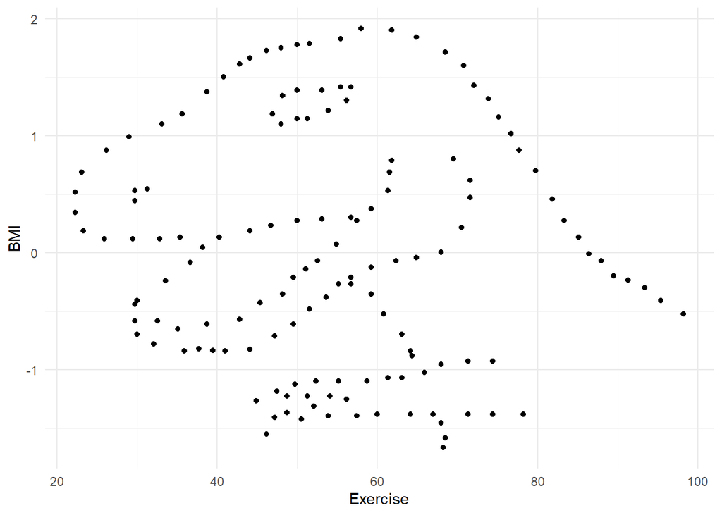

```r
ggplot(exercise_data,
       aes(x = Exercise,
           y = BMI)) +
       geom_point()
```

The graph looks like a dinosaur.

## Question 2

```r
library(causact)
glimpse(corruptDF)
```

```
Rows: 174
Columns: 7
$ country     <chr> "Afghanistan", "Albania", "Algeria", "Angola", "Argentina"…
$ region      <chr> "Asia Pacific", "East EU Cemt Asia", "MENA", "SSA", "Ameri…
$ countryCode <chr> "AFG", "ALB", "DZA", "AGO", "ARG", "ARM", "AUS", "AUT", "A…
$ regionCode  <chr> "AP", "ECA", "MENA", "SSA", "AME", "ECA", "AP", "WE/EU", "…
$ population  <int> 35530081, 2873457, 41318142, 29784193, 44271041, 2930450, …
$ CPI2017     <int> 15, 38, 33, 19, 39, 35, 77, 75, 31, 65, 36, 28, 68, 44, 75…
$ HDI2017     <dbl> 0.498, 0.785, 0.754, 0.581, 0.825, 0.755, 0.939, 0.908, 0.…
```

```r
?corruptDF
```

```
starting httpd help server ... done
```

CPI2017 captures the Corruption Perceptions Index score for 2017 which demonstrates a country/territory’s perceived public sector corruption on a scale of 0-100, where the higher the score the less corrupt. HDI2017 captures the Human Development Index for 2017 which measures achievement of a nation’s longevity, education and income from a simple unweighted average.

## Question 3

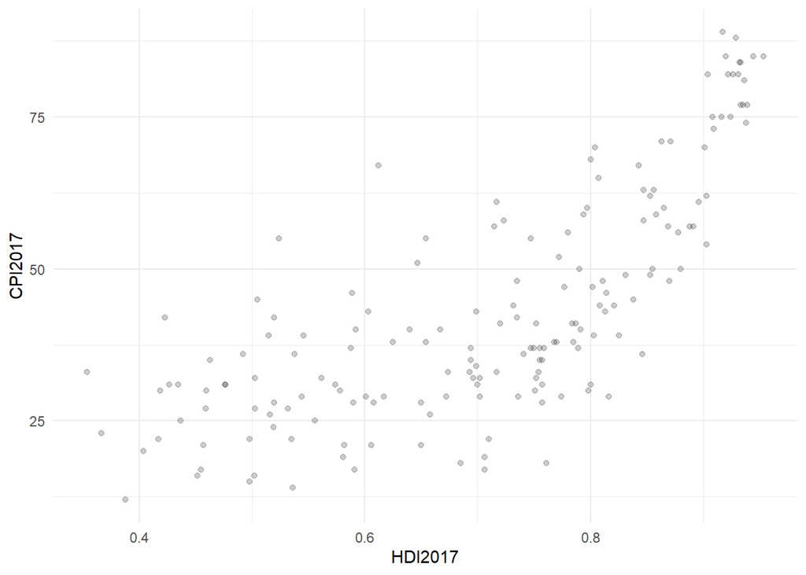

```r
ggplot(corruptDF,
       aes(x = HDI2017,
           y = CPI2017)) +
  geom_point(alpha = .2)
```

The CPI and HDI for 2017 seem to have a positive relationship, meaning that country’s that have a higher CPI score also have a higher HDI measure. However, they are not that strongly correlated as the data is relatively spread out.

## Question 4

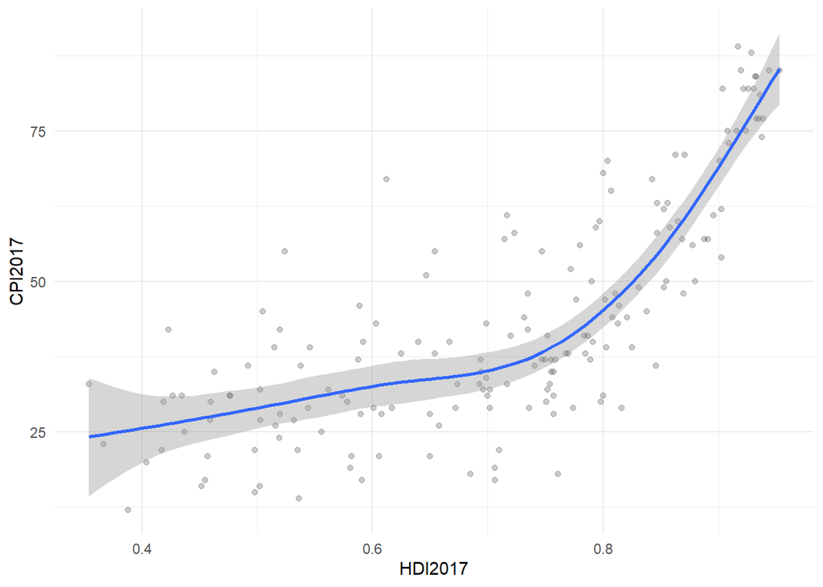

```r
ggplot(corruptDF,
       aes(x = HDI2017,
           y = CPI2017)) +
  geom_point(alpha = .2) +
  geom_smooth(method = "gam")
```

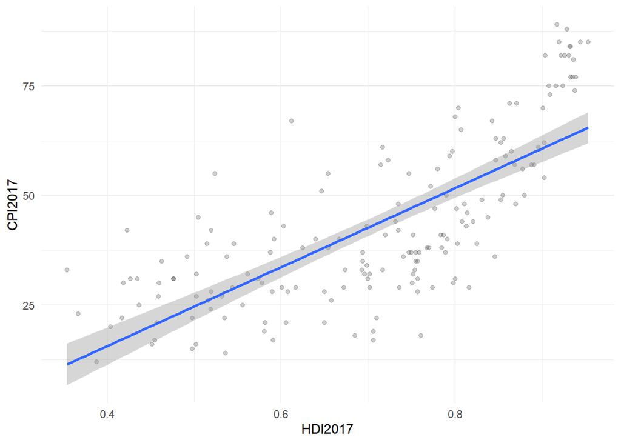

```r
ggplot(corruptDF,
       aes(x = HDI2017,
           y = CPI2017)) +
  geom_point(alpha = .2) +
  geom_smooth(method = "lm")
```

The difference is that the gam method is not a straight line and follows the average of the points while the lm method is a straight line and demonstrates the steady increase. I prefer the lm method because it follows normal distribution more closely.

## Question 5

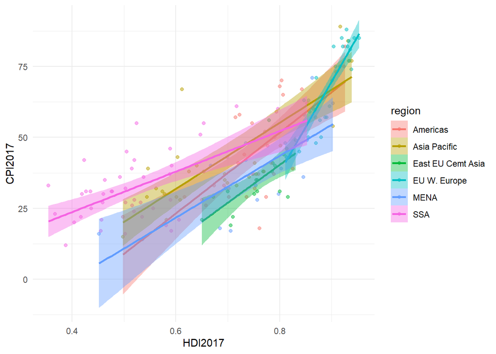

```r
ggplot(corruptDF,
       aes(x = HDI2017,
           y = CPI2017,
           color = region,
           fill = region)) +
  geom_point(alpha = .5) +
  geom_smooth(method = "lm")
```

The graph is too cluttered to see the differences by region.

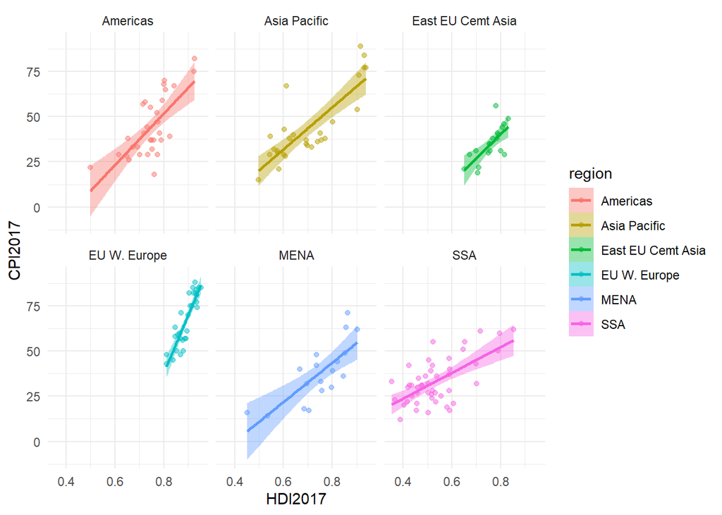

```r
ggplot(corruptDF,
       aes(x = HDI2017,
           y = CPI2017,
           color = region,
           fill = region)) +
  geom_point(alpha = .5) +
  geom_smooth(method = "lm") +
  facet_wrap(~region)
```

## Question 6

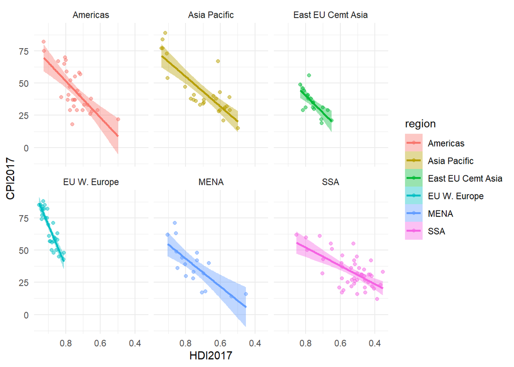

```r
ggplot(corruptDF,
       aes(x = HDI2017,
           y = CPI2017,
           color = region,
           fill = region)) +
  geom_point(alpha = .5) +
  geom_smooth(method = "lm") +
  facet_wrap(~region) +
  scale_x_reverse()
```

## Question 7

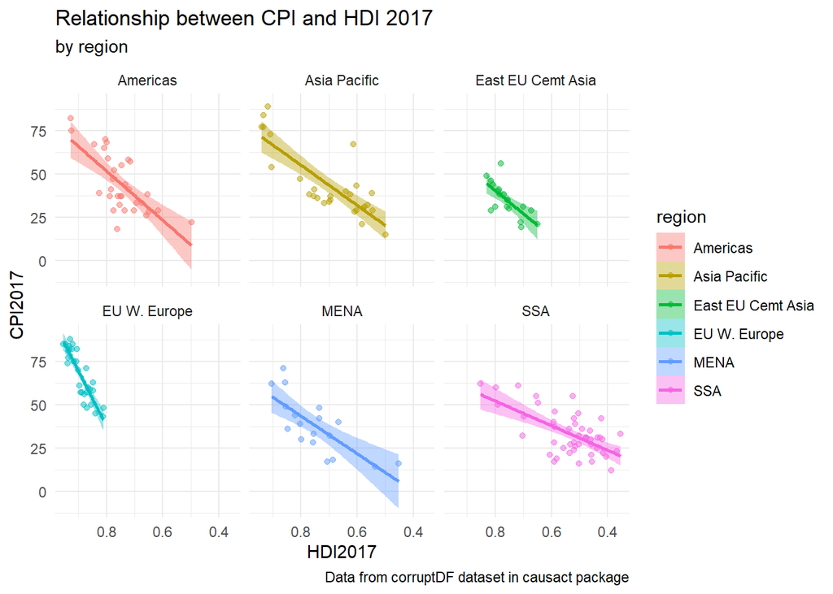

```r
ggplot(corruptDF,
       aes(x = HDI2017,
           y = CPI2017,
           color = region,
           fill = region)) +
  geom_point(alpha = .5) +
  geom_smooth(method = "lm") +
  facet_wrap(~region) +
  scale_x_reverse() +
  labs(title = "Relationship between CPI and HDI 2017",
       subtitle = "by region",
       caption = "Data from corruptDF dataset in causact package")
```

## Question 8

```r
ggsave(filename = "CPI&HDIPlot.png")
```